# Bandit Algorithms: Getting More Lunch Money

## Artem Yankov

### Data Scientist at Rover.com

Contact me!

- yankovai@umich.edu
- 1oclockbuzz.com
- All code used in this presentation can be found at github.com/yankovai

## Outline

- A motivating example using Bayesian Bandits
- Other Bandit Algorithms
- Getting more lunch money
- Caveats
- References for further exploration

# An Example

## One-Armed Bandit

[figure not shown]

## Multi-Armed Bandit Problem

- Say we are faced with K one-armed bandits
- Each has an unknown payoff
- At each turn we choose a bandit and pull
  - The bandit either pays money out, or not
- What strategy should we use to optimize our earnings?

## Model the Problem

$$ \begin{equation} P(r_i | n_i, w_i) = \frac{P(n_i, w_i | r_i)P(r_i)}{P(n_i, w_i)} \end{equation} $$

- Update our belief about each bandit's payoff rate as we continue playing
- Sounds like a problem for Bayes' Theorem
- $r_i =$ Payoff rate of bandit $i$
- $n_i =$ Number of times bandit $i$ has been played
- $w_i =$ Number of times we've won with bandit $i$

## Prior

- Seems natural to model the prior $P(r_i)$ as a beta distribution $\beta(a, b)$
  - Domain is from 0 to 1
- Initially we have no reason to believe one bandit pays out at a higher rate than the others
  - The beta distribution is the uniform distribution for $\beta(a=1, b=1)$

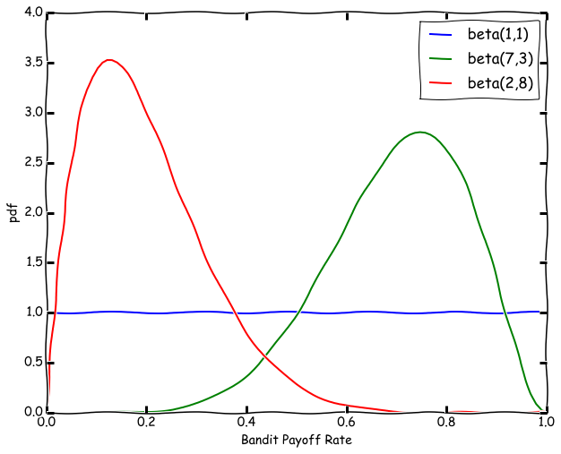

```python
figsize(10,8)
x = np.linspace(0, 1, 100)
b_11, b_73, b_28 = beta(1, 1), beta(7, 3), beta(2, 8)
plt.plot(x, b_11.pdf(x), color='b', label='beta(1,1)')
plt.plot(x, b_73.pdf(x), color='g', label='beta(7,3)')
plt.plot(x, b_28.pdf(x), color='r', label='beta(2,8)')
plt.legend(loc='best')
plt.xlabel('Bandit Payoff Rate')
plt.ylabel('pdf');
```

## Likelihood

- Given an expected payoff rate, what's the probability of having $w_i$ wins out of $n_i$ trials?
  - The binomial distribution gives this to us

$$P(n_i, w_i | r_i) = {n_i \choose w_i}r_i^{w_i} (1 - r_i)^{n_i - w_i} $$

## Posterior

- The beta distribution is the conjugate prior for the binomial distribution
  - When you multiply the beta distribution by the binomial you get a beta distribution back!
- Skipping the math, if we assume a beta prior $\beta(a,b)$ the posterior becomes:

$$P(r_i | n_i, w_i) = \beta(a + w_i, b + n_i - w_i)$$

## Bayesian Bandit Algorithm

1. For each of K bandits, set $\beta(1,1)$ (uniform distribution)
2. At each turn:
   - Take a sample from each bandit's beta distribution
   - Choose the bandit that yielded the largest sample
   - Play the bandit
   - Update the bandit's distribution based on the result of the pull

## Simulation

- Say we have 3 bandits
  - Payoff of bandit 0 = 0.55
  - Payoff of bandit 1 = 0.71
  - Payoff of bandit 2 = 0.29
- Pretend the player faced with getting the most money out of the bandits doesn't know their true payoffs
- How does the bandit algorithm perform?

```python
class Bandit:

    def __init__(self, r):
        self.r = r
        self.n = 0
        self.w = 0

    def pull(self):
        return (np.random.rand() < self.r)

    def update(self, result):
        self.n += 1
        if result:
            self.w += 1

    def sample(self):
        return (np.random.beta(1 + self.w, 1 + self.n - self.w))
```

### Bandit PDFs

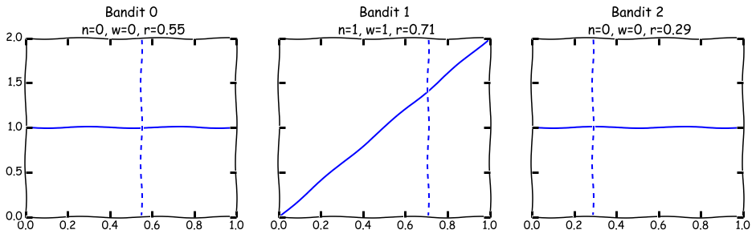

```python
figsize(16,4)
plot_bandit_pdfs(n_rounds=1)
```

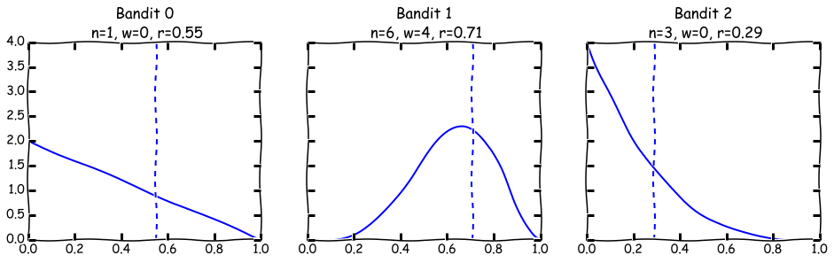

```python
figsize(16,4)
plot_bandit_pdfs(n_rounds=10)
```

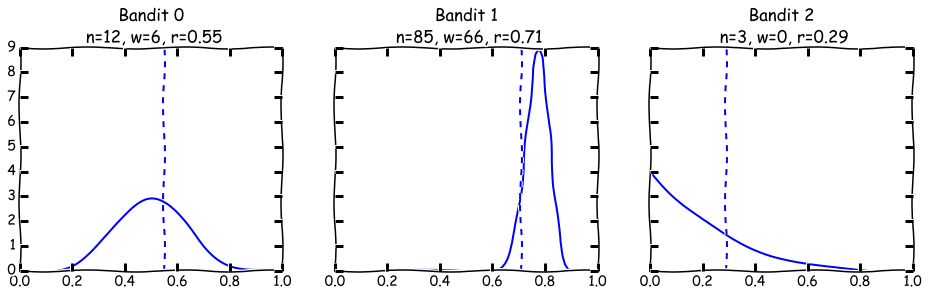

```python
figsize(16,4)
plot_bandit_pdfs(n_rounds=100)
```

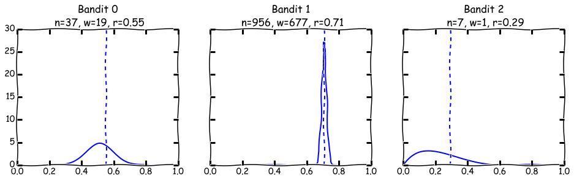

```python
figsize(16,4)
plot_bandit_pdfs(n_rounds=1000)
```

## Analysis

### Average Reward

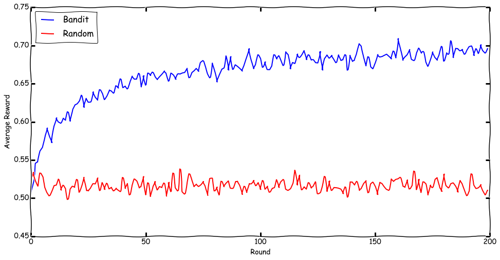

```python
figsize(16,8)
plot_avg_reward(bresults, rresults, n_rounds=N_ROUNDS)
```

### Fraction of Time Each Bandit is Chosen

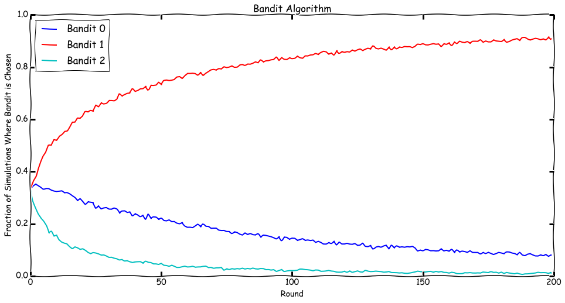

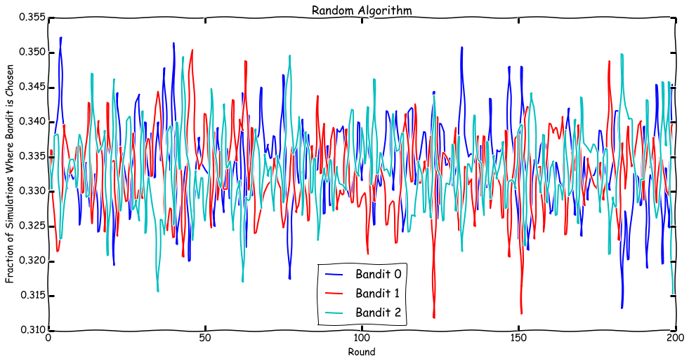

```python
figsize(16,8)
plot_chosen_bandit(bresults, rresults, n_rounds=N_ROUNDS, n_sims=N_SIMS)
```

### Cumulative Regret

- Captures lost earnings if you were an omnipotent player
- Any strategy that yields logarithmic growing regret is said to "solve" the Bandit Problem

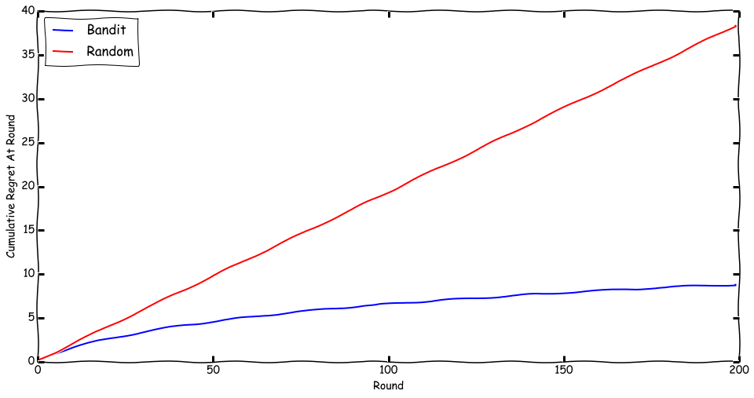

```python
figsize(16,8)
plot_cuml_regret(bresults, rresults, max(bandit_payoff_rates), n_rounds=N_ROUNDS)
```

## Discussion

- Exploration vs Exploitation
- A/B Testing

# Other Bandit Algorithms

## Epsilon-Greedy

- The simplest Bandit Algorithm out there
- "Epsilon" is the probability of algorithm exploring instead of exploiting at each round
1. For each of K bandits, initialize average reward to 0
2. At each turn:
   - Generate a random number between 0 and 1
   - If $> \epsilon$
     - Choose the bandit with current highest average reward
   - If $\leq \epsilon$
     - Choose any bandit at random
   - Play the chosen bandit
   - Update the bandit's average reward based on the result of the pull

## UCB1 (Upper Confidence Bound)

- Takes into account the uncertainty in the average reward of any given bandit
- Rewards must be between 0 and 1
- Doesn't use randomness at all
- No need to set hyperparameters
1. For each of K bandits, play each one once
2. At each turn:
   - Select bandit with largest $\mu_i + \sqrt{2\log{(T)}/n_i}$ where $\mu_i$ is average reward of bandit $i$, $n_i$ is number of times the bandit has been played, and $T$ is the total number of plays
   - Play the chosen bandit
   - Update the bandit's average reward based on the result of the pull

## Where Does $\sqrt{2\log{(T)}/n_i}$ Come From?

- Chernoff-Hoeffding inequality
  - Distribution independent relation for the probability that true expected payoff is less than an upper bound
- For a given bandit, let $Y_1, Y_2, ..., Y_n$ be independent random variables in $[0,1]$ (i.e. outcomes of playing the bandit)
- Let the expected value of each $Y_j$ be $\mu_j$
  - The average observed reward is $Y = (1/n) \sum Y_j$
  - Then $\mu = \mathbf{E}(Y) = (1/n) \sum \mu_j$
- The Chernoff-Hoeffding inequality says

$$ P(Y > \mu + a) \leq e^{-2na^2}$$

- For the UCB1 algorithm we let $a = \sqrt{2\log(T)/n}$
  - Then $P(Y > \mu + a) \leq T^{-4}$

## Stochastic vs Adversarial Bandits

- The bandit algorithms we've dealt with so far are of the stochastic variety
  - Each bandit has an unknown payoff. We model our knowledge about the payoff using a distribution
- There are also adversarial bandits
  - It's you vs an omnipotent and evil player who can change the bandits' rewards at any time
  - Adversarial bandit is trying to maximize your regret
- Exp3 Algorithm is designed to deal with the adversarial bandit problem

# Getting More Lunch Money

## The Scenerio

- Browning McClementine bullies his fellow classmates to be able to buy lattes from Cindy Carrots, his crush
- Lunch costs $1, but not every child can afford to bring lunch every day

| Kid | Name | P(lunch money) |
| --- | --- | --- |
| 0 | Bob | 0.55 |
| 1 | Ben | 0.71 |
| 2 | Dan | 0.29 |
| 3 | Don | 0.51 |
| 4 | Eli | 0.89 |
| 5 | Gus | 0.90 |
| 6 | Jim | 0.13 |
| 7 | Pat | 0.21 |
| 8 | Ray | 0.05 |
| 9 | Sam | 0.44 |

- If Browning decides to bully the same student three days in a row, the student would smarten up and stop bringing lunch money for 5 consecutive days
  - If Browning attempts to bully such a student during the 5 day hiatus, the student would reset the 5 day no-lunch money period

## If Browning Used UCB1 to Decide Who to Bully

- ... and classmates never smartened up

[figure not shown]

## Browning Used Exp3 to Decide Who To Bully

- ... And classmates behaved adversarially

[figure not shown]

- Exp3 Algorithm mitigates classmates adversarial nature by picking randomly once in a while

[figure not shown]

# Watch Out!

- Why would you ever use traditional A/B testing again?
- Out of the box bandit algorithms rarely work as intended
  - Samples drawn from each bandit must be independent and identically distributed
  - The payoff rates do not change over time
  - There is no delay between pulling an arm and observing the result

## Day of Week Problem

- Say New England Patriots just won the superbowl and you’re trying to sell t-shirts on the web
  - Variant A: Happy Monday! New England Patriots, Superbowl Champs
  - Variant B: Get your New England Patriots t-shirt today!

| Day of Week | A Displays | A Sales | B Displays | B Sales |
| --- | --- | --- | --- | --- |
| Monday | 1000 | 100 | 1000 | 50 |
| Tuesday | 1900 | 100 | 100 | 10 |
| Wednesday | 1900 | 100 | 100 | 10 |
| Thursday | 1900 | 100 | 100 | 10 |
| Friday | 1900 | 100 | 100 | 100 |

## Payoff Rates Not Constant

- Can be remedied using adversarial bandit algorithms
- If using stochastic bandit algorithms can incorporate a learning rate
  - e.g. when calculating average reward weigh recent results more
    - $r_i \equiv (1-\alpha)r_{i-1} + \alpha r_i$

## Delayed Feedback

- Use batch processing techniques
- Don't change your metric to accommodate bandit algorithms
  - e.g. unique visitors to unique sessions. This will lead to correlated samples

## Other Tweaks

- Use A/A tests
- Monte Carlo simulations to test everything
- Conextual bandits
  - Use machine learning to decide which bandit to pull
- Correlated bandits
  - Might occur if you're testing many variants
- Hierarchical algorithms
  - Bayesian bandit algorithms on top of smaller bandit algorithms

# Resources

## Easy

- [Chris Stucchio's Blog](https://www.chrisstucchio.com/blog/2013/bayesian_bandit.html)
- [Cameron Davidson-Pilon's Blog](https://dataorigami.net/blogs/napkin-folding/79031811-multi-armed-bandits)
- Bandit Algorithms for Website Optimization by John Myles White

## Medium

- [Jeremy Kun on Probabilistic Bounds](http://jeremykun.com/2013/04/15/probabilistic-bounds-a-primer/)
- [Jeremy Kun on UCB1](http://jeremykun.com/2013/10/28/optimism-in-the-face-of-uncertainty-the-ucb1-algorithm/)
- [Jeremy Kun on Exp3](http://jeremykun.com/2013/11/08/adversarial-bandits-and-the-exp3-algorithm/)
- Reinforcement Learning: An Introduction by Richard S. Sutton and Andrew G. Barto

## Hard

- [Gittins Index](http://www.statslab.cam.ac.uk/~rrw1/talks/gocps.pdf)
- [The Non-Stochastic Multi-Armed Bandit](http://cseweb.ucsd.edu/~yfreund/papers/bandits.pdf)
- [Thompson Sampling for Contextual Bandits with Linear Payoffs](http://jmlr.csail.mit.edu/proceedings/papers/v28/agrawal13.pdf)

# That's All

## Thanks for following along

### Any Questions?

- Feel free to email me